# Explore_bikeshare_data

### Explore Bike Share Data

For this project, your goal is to ask and answer three questions about the available bikeshare data from Washington, Chicago, and New York. This notebook can be submitted directly through the workspace when you are confident in your results.

You will be graded against the project [Rubric](https://review.udacity.com/#!/rubrics/2508/view) by a mentor after you have submitted. To get you started, you can use the template below, but feel free to be creative in your solutions!

```r
library(ggplot2)
ny = read.csv('new_york_city.csv')
wash = read.csv('washington.csv')
chi = read.csv('chicago.csv')
```

```r
head(ny)
```

| X | Start.Time | End.Time | Trip.Duration | Start.Station | End.Station | User.Type | Gender | Birth.Year |
| --- | --- | --- | --- | --- | --- | --- | --- | --- |
| 5688089 | 2017-06-11 14:55:05 | 2017-06-11 15:08:21 | 795 | Suffolk St & Stanton St | W Broadway & Spring St | Subscriber | Male | 1998 |
| 4096714 | 2017-05-11 15:30:11 | 2017-05-11 15:41:43 | 692 | Lexington Ave & E 63 St | 1 Ave & E 78 St | Subscriber | Male | 1981 |
| 2173887 | 2017-03-29 13:26:26 | 2017-03-29 13:48:31 | 1325 | 1 Pl & Clinton St | Henry St & Degraw St | Subscriber | Male | 1987 |
| 3945638 | 2017-05-08 19:47:18 | 2017-05-08 19:59:01 | 703 | Barrow St & Hudson St | W 20 St & 8 Ave | Subscriber | Female | 1986 |
| 6208972 | 2017-06-21 07:49:16 | 2017-06-21 07:54:46 | 329 | 1 Ave & E 44 St | E 53 St & 3 Ave | Subscriber | Male | 1992 |
| 1285652 | 2017-02-22 18:55:24 | 2017-02-22 19:12:03 | 998 | State St & Smith St | Bond St & Fulton St | Subscriber | Male | 1986 |

```r
head(wash)
```

| X | Start.Time | End.Time | Trip.Duration | Start.Station | End.Station | User.Type |
| --- | --- | --- | --- | --- | --- | --- |
| 1621326 | 2017-06-21 08:36:34 | 2017-06-21 08:44:43 | 489.066 | 14th & Belmont St NW | 15th & K St NW | Subscriber |
| 482740 | 2017-03-11 10:40:00 | 2017-03-11 10:46:00 | 402.549 | Yuma St & Tenley Circle NW | Connecticut Ave & Yuma St NW | Subscriber |
| 1330037 | 2017-05-30 01:02:59 | 2017-05-30 01:13:37 | 637.251 | 17th St & Massachusetts Ave NW | 5th & K St NW | Subscriber |
| 665458 | 2017-04-02 07:48:35 | 2017-04-02 08:19:03 | 1827.341 | Constitution Ave & 2nd St NW/DOL | M St & Pennsylvania Ave NW | Customer |
| 1481135 | 2017-06-10 08:36:28 | 2017-06-10 09:02:17 | 1549.427 | Henry Bacon Dr & Lincoln Memorial Circle NW | Maine Ave & 7th St SW | Subscriber |
| 1148202 | 2017-05-14 07:18:18 | 2017-05-14 07:24:56 | 398.000 | 1st & K St SE | Eastern Market Metro / Pennsylvania Ave & 7th St SE | Subscriber |

```r
head(chi)
```

| X | Start.Time | End.Time | Trip.Duration | Start.Station | End.Station | User.Type | Gender | Birth.Year |
| --- | --- | --- | --- | --- | --- | --- | --- | --- |
| 1423854 | 2017-06-23 15:09:32 | 2017-06-23 15:14:53 | 321 | Wood St & Hubbard St | Damen Ave & Chicago Ave | Subscriber | Male | 1992 |
| 955915 | 2017-05-25 18:19:03 | 2017-05-25 18:45:53 | 1610 | Theater on the Lake | Sheffield Ave & Waveland Ave | Subscriber | Female | 1992 |
| 9031 | 2017-01-04 08:27:49 | 2017-01-04 08:34:45 | 416 | May St & Taylor St | Wood St & Taylor St | Subscriber | Male | 1981 |
| 304487 | 2017-03-06 13:49:38 | 2017-03-06 13:55:28 | 350 | Christiana Ave & Lawrence Ave | St. Louis Ave & Balmoral Ave | Subscriber | Male | 1986 |
| 45207 | 2017-01-17 14:53:07 | 2017-01-17 15:02:01 | 534 | Clark St & Randolph St | Desplaines St & Jackson Blvd | Subscriber | Male | 1975 |
| 1473887 | 2017-06-26 09:01:20 | 2017-06-26 09:11:06 | 586 | Clinton St & Washington Blvd | Canal St & Taylor St | Subscriber | Male | 1990 |

### Question 1

**What is the Average Trip Duration by City?.**

```r
#adding a city column to each table so they will be identifiable when joined in one dataset
chi$City <- 'Chicago'
ny$City <- 'New York'
wash$City <- 'Washington'
#adding missing columns with null values to Washington data set for consistency when joining
wash$Gender <- NA
wash$Birth.Year <- NA

# combining the 3 datasets into one known as city_data
city_data <- rbind(ny, wash)
city_data <- rbind(city_data, chi)
head(city_data)
```

| X | Start.Time | End.Time | Trip.Duration | Start.Station | End.Station | User.Type | Gender | Birth.Year | City |
| --- | --- | --- | --- | --- | --- | --- | --- | --- | --- |
| 5688089 | 2017-06-11 14:55:05 | 2017-06-11 15:08:21 | 795 | Suffolk St & Stanton St | W Broadway & Spring St | Subscriber | Male | 1998 | New York |
| 4096714 | 2017-05-11 15:30:11 | 2017-05-11 15:41:43 | 692 | Lexington Ave & E 63 St | 1 Ave & E 78 St | Subscriber | Male | 1981 | New York |
| 2173887 | 2017-03-29 13:26:26 | 2017-03-29 13:48:31 | 1325 | 1 Pl & Clinton St | Henry St & Degraw St | Subscriber | Male | 1987 | New York |
| 3945638 | 2017-05-08 19:47:18 | 2017-05-08 19:59:01 | 703 | Barrow St & Hudson St | W 20 St & 8 Ave | Subscriber | Female | 1986 | New York |
| 6208972 | 2017-06-21 07:49:16 | 2017-06-21 07:54:46 | 329 | 1 Ave & E 44 St | E 53 St & 3 Ave | Subscriber | Male | 1992 | New York |
| 1285652 | 2017-02-22 18:55:24 | 2017-02-22 19:12:03 | 998 | State St & Smith St | Bond St & Fulton St | Subscriber | Male | 1986 | New York |

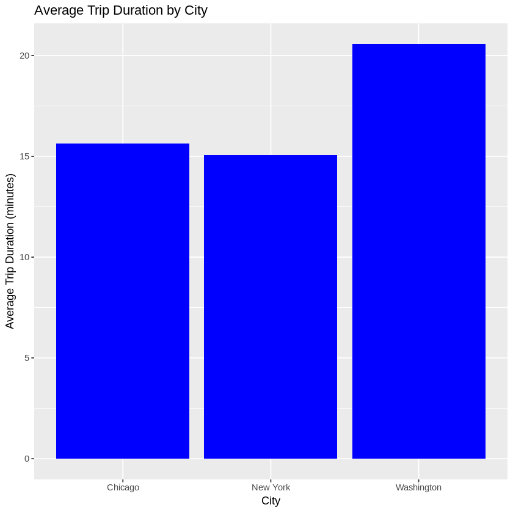

```r
# Convert Trip.Duration to minutes
city_data$Trip.Duration_Minutes <- city_data$Trip.Duration / 60

# Plot the bar chart for average trip duration.
ggplot(city_data, aes(x = City, y = Trip.Duration_Minutes)) +
  geom_bar(stat = "summary", fun = "mean", position = "dodge", fill = "blue") +
  labs(title = "Average Trip Duration by City",
       x = "City",
       y = "Average Trip Duration (minutes)")
```

```r
# Calculate and display average trip duration for each city.
trip_summary <- with(city_data, aggregate(list(Trip.Duration), by = list(City),
                                   FUN = function(x) mean(x / 60, na.rm = TRUE)))
colnames(trip_summary) <- c('City', 'Average_Trip_Duration_Minutes')

trip_summary
```

| City | Average_Trip_Duration_Minutes |
| --- | --- |
| Chicago | 15.61955 |
| New York | 15.06024 |
| Washington | 20.56589 |

### Question 2

**Breakdown of Riders by Gender(New York & Chicago only)**

```r
# creating dataframe composed of only Chicago and New York called 'two_city'
two_city <- rbind(chi, ny)
head(two_city)
```

| X | Start.Time | End.Time | Trip.Duration | Start.Station | End.Station | User.Type | Gender | Birth.Year | City |
| --- | --- | --- | --- | --- | --- | --- | --- | --- | --- |
| 1423854 | 2017-06-23 15:09:32 | 2017-06-23 15:14:53 | 321 | Wood St & Hubbard St | Damen Ave & Chicago Ave | Subscriber | Male | 1992 | Chicago |
| 955915 | 2017-05-25 18:19:03 | 2017-05-25 18:45:53 | 1610 | Theater on the Lake | Sheffield Ave & Waveland Ave | Subscriber | Female | 1992 | Chicago |
| 9031 | 2017-01-04 08:27:49 | 2017-01-04 08:34:45 | 416 | May St & Taylor St | Wood St & Taylor St | Subscriber | Male | 1981 | Chicago |
| 304487 | 2017-03-06 13:49:38 | 2017-03-06 13:55:28 | 350 | Christiana Ave & Lawrence Ave | St. Louis Ave & Balmoral Ave | Subscriber | Male | 1986 | Chicago |
| 45207 | 2017-01-17 14:53:07 | 2017-01-17 15:02:01 | 534 | Clark St & Randolph St | Desplaines St & Jackson Blvd | Subscriber | Male | 1975 | Chicago |
| 1473887 | 2017-06-26 09:01:20 | 2017-06-26 09:11:06 | 586 | Clinton St & Washington Blvd | Canal St & Taylor St | Subscriber | Male | 1990 | Chicago |

```r
summary(two_city)
#inspecting new dataframe, we see a 'mystery' count that is untitled under gender.
```

```
       X                         Start.Time                   End.Time
 Min.   :     36   2017-05-11 18:26:10:    3   2017-01-05 17:24:45:    2
 1st Qu.:1177344   2017-01-02 14:40:49:    2   2017-01-13 08:14:44:    2
 Median :2877789   2017-01-24 07:30:45:    2   2017-02-15 18:26:36:    2
 Mean   :3056632   2017-01-24 07:40:32:    2   2017-02-18 12:24:46:    2
 3rd Qu.:4852807   2017-01-26 17:07:58:    2   2017-02-27 17:14:27:    2
 Max.   :6816152   2017-02-08 07:24:28:    2   2017-03-04 13:28:34:    2
                   (Other)            :63387   (Other)            :63388
 Trip.Duration                     Start.Station
 Min.   :     60.0   Pershing Square North:  592
 1st Qu.:    371.0   W 21 St & 6 Ave      :  385
 Median :    617.0   Broadway & E 22 St   :  383
 Mean   :    908.2   E 17 St & Broadway   :  380
 3rd Qu.:   1060.0   West St & Chambers St:  364
 Max.   :1088634.0   W 20 St & 11 Ave     :  329
 NA's   :1           (Other)              :60967
                End.Station         User.Type        Gender        Birth.Year
 Pershing Square North:  556             :  120         : 7158   Min.   :1885
 E 17 St & Broadway   :  445   Customer  : 7304   Female:13882   1st Qu.:1970
 Broadway & E 22 St   :  427   Subscriber:55976   Male  :42360   Median :1981
 W 21 St & 6 Ave      :  365                                     Mean   :1979
 W 20 St & 11 Ave     :  344                                     3rd Qu.:1988
 W 38 St & 8 Ave      :  338                                     Max.   :2002
 (Other)              :60925                                     NA's   :6965
     City
 Length:63400
 Class :character
 Mode  :character
```

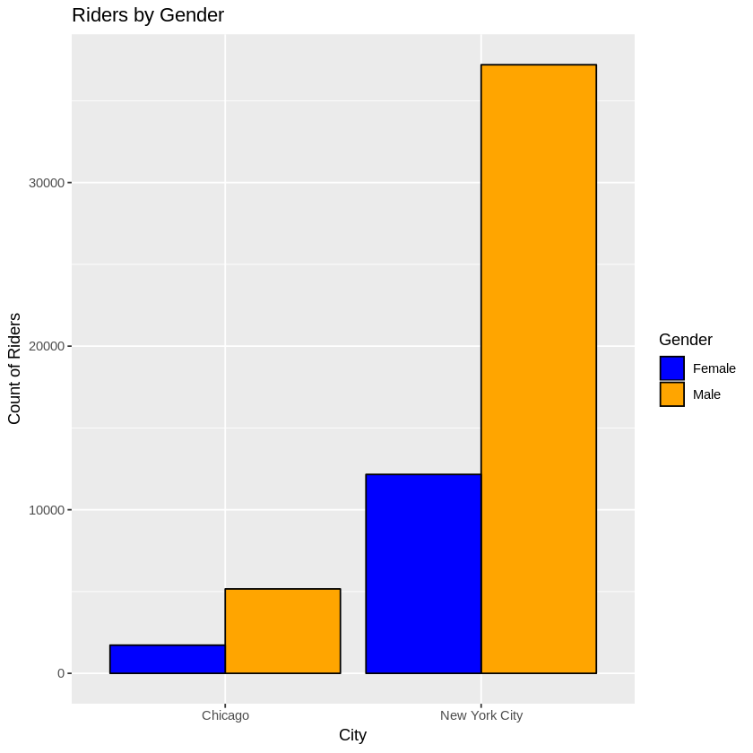

```r
# Filtering gender column to only male and female
filtered_gen <- two_city[two_city$Gender %in% c("Female", "Male"), ]

#plotting bar chart
ggplot(aes(x = City, fill = as.factor(Gender)), data = filtered_gen) +
  geom_bar(position = 'dodge', colour = "black") +
  ggtitle('Riders by Gender') +
  scale_x_discrete(labels = c('Chicago', 'New York City')) +
  labs(y = 'Count of Riders', x = 'City') +
  scale_fill_manual(values = c("Female" = "blue", "Male" = "orange")) +
  guides(fill = guide_legend(title = "Gender"))
```

```r
#Show total population of dataset broken down by gender(whole number and percent)
gen_total = sort(table(two_city$Gender))
print(gen_total)
round((gen_total / length(two_city$Gender) * 100), digits =2)
```

```
       Female   Male
  7158  13882  42360
```

```
       Female   Male
 11.29  21.90  66.81
```

```r
#Create function to calculate percent of riders per city by gender
gender_percentage <- function(data, city_column, gender_column, target_gender) {

  gender_table <- table(data[[city_column]], data[[gender_column]])

  gender_counts <- gender_table[, target_gender]

  total_counts <- rowSums(gender_table)

  percentage_data <- data.frame(
    City = names(gender_counts),
    Percentage_Target = (gender_counts / total_counts) * 100
  )

  return(percentage_data)
}

#Finding male rider percentage within each city
gender_percentage_data <- gender_percentage(two_city, "City", "Gender", "Male")
print(gender_percentage_data)

#Percentage of male riders below
```

```
             City Percentage_Target
Chicago   Chicago          59.77984
New York New York          67.92222
```

```r
#Using function to find female rider percentage within each city
gender_percentage_data <- gender_percentage(two_city, "City", "Gender", "Female")
print(gender_percentage_data)
#Percentage of female riders below
```

```
             City Percentage_Target
Chicago   Chicago          19.96524
New York New York          22.20011
```

**Summary** Here we are looking at the riders in each city based on gender. We are only looking at New York and Chicago as they have actual data on this(Washington does not). After creating this table, we ran a summary and saw the counts of both male and female. However, we also saw a third count under gender which was untitled. Were these people who didn't feel comfortable specifying thier gender? Or perhaps it was simply a key error by the person entering the data. Considering thier are several reasons why it could be this way and we have no way to accurately determine why, it will be best to not take this 'untitled' count of gender into our analysis. Therefore, we only looked at those listed as 'male' or 'female'. When looking at this chart, we see a strong correlation indicating males are more likely to be a rider in either city. Males riders account for 59% of riders in Chicago and 67% of riders in New York. Female riders, on the other hand, have much lower rates. Females account for only 19% of riders in Chicago, and 22% of riders in New York.

### Question 3

**Bikeshare User Type by City.**

```r
# inspecting data, we see another 'mystery' count under User.Type that is not subscriber/customer.
summary(city_data)
```

```
       X                         Start.Time                    End.Time
 Min.   :      7   2017-02-19 12:19:00:     6   2017-03-09 17:54:00:     7
 1st Qu.: 589310   2017-02-20 11:35:00:     6   2017-03-28 18:11:00:     7
 Median :1184899   2017-02-24 17:46:00:     6   2017-01-13 17:48:00:     6
 Mean   :1781625   2017-03-01 08:20:00:     6   2017-01-31 08:49:00:     6
 3rd Qu.:2085970   2017-03-02 08:39:00:     6   2017-02-13 18:09:00:     6
 Max.   :6816152   2017-03-09 17:31:00:     6   2017-02-20 11:38:00:     6
                   (Other)            :152415   (Other)            :152413
 Trip.Duration                                  Start.Station
 Min.   :     60   Columbus Circle / Union Station     :  1700
 1st Qu.:    392   Lincoln Memorial                    :  1546
 Median :    667   Jefferson Dr & 14th St SW           :  1488
 Mean   :   1098   Massachusetts Ave & Dupont Circle NW:  1219
 3rd Qu.:   1159   Jefferson Memorial                  :  1068
 Max.   :1088634   15th & P St NW                      :  1040
 NA's   :2         (Other)                             :144390
                                                End.Station
 Columbus Circle / Union Station                      :  1767
 Jefferson Dr & 14th St SW                            :  1603
 Lincoln Memorial                                     :  1514
 Massachusetts Ave & Dupont Circle NW                 :  1344
 Smithsonian-National Mall / Jefferson Dr & 12th St SW:  1103
 15th & P St NW                                       :  1077
 (Other)                                              :144043
      User.Type         Gender        Birth.Year        City
           :   121         : 7158   Min.   :1885    Length:152451
 Customer  : 30754   Female:13882   1st Qu.:1970    Class :character
 Subscriber:121576   Male  :42360   Median :1981    Mode  :character
                     NA's  :89051   Mean   :1979
                                    3rd Qu.:1988
                                    Max.   :2002
                                    NA's   :96016
 Trip.Duration_Minutes
 Min.   :    1.000
 1st Qu.:    6.533
 Median :   11.117
 Mean   :   18.308
 3rd Qu.:   19.312
 Max.   :18143.900
 NA's   :2
```

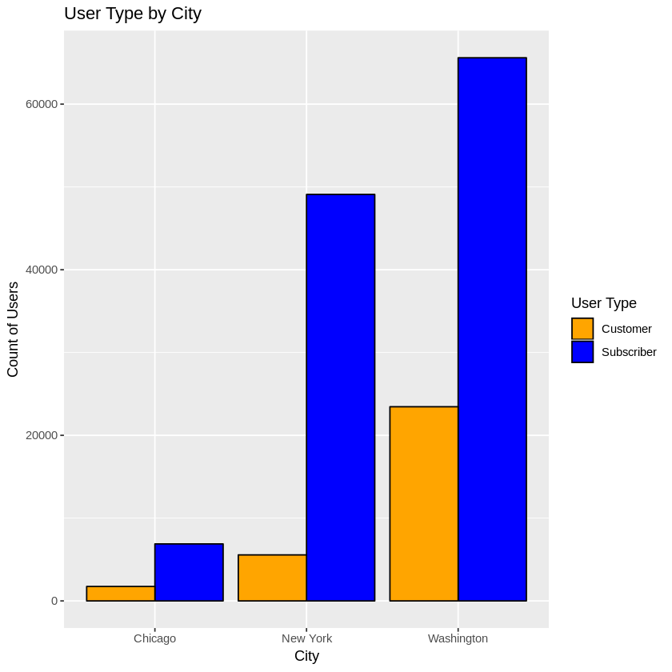

```r
# Filter the data for 'Subscriber' and 'Customer'
bike_user_type <- city_data[city_data$User.Type %in% c("Subscriber", "Customer"), ]

#Plot data in bar chart
ggplot(aes(x = City, fill = as.factor(User.Type)), data = bike_user_type) +
  geom_bar(position = 'dodge', colour = "black") +
  ggtitle('User Type by City') +
  labs(y = 'Count of Users', x = 'City') +
  scale_fill_manual(values = c("Subscriber" = "blue", "Customer" = "orange")) +
  guides(fill = guide_legend(title = "User Type"))
```

```r
#Create function to calculate percentage of subscribers/customers per city
calculate_percentage_user_type <- function(data, user_type) {

  type_data <- data[data$User.Type == user_type, ]

  total_counts <- table(data$City)

  user_type_counts <- table(type_data$City)

  percentage <- (user_type_counts / total_counts) * 100

  result <- data.frame(City = names(percentage), Percentage = as.numeric(percentage))

  return(result)
}


# Calculate percentage for 'Subscriber' using function and display
subscriber_percentage <- calculate_percentage_user_type(city_data, 'Subscriber')
print(subscriber_percentage)
#percentage for subscribers below
```

```
        City Percentage
1    Chicago   79.75666
2   New York   89.63484
3 Washington   73.66565
```

```r
# Calculate percentage for 'Customer' using function and display
customer_percentage <- calculate_percentage_user_type(city_data, 'Customer')
print(customer_percentage)
#percentage for customers below
```

```
        City Percentage
1    Chicago   20.23175
2   New York   10.14789
3 Washington   26.33322
```

**Summary** We can see from this chart that an overwhelming number of users are subscribers among all cities, with rates as high as 89%. This data shows a strong correlation between using a bike share service and being a subscriber. The rates for subscribers are New York = 89%, Chicago = 79%, and Washington = 73%. You can also see the rates for customers above which are considerably lower. It should be noted, in preparing this data, we did find a 'mystery' count under UserType when viewing summary. 'Mystery' type meaning we see a number, but no title attached too it.(i.e. customer or subscriber). Because of this, we filtered the data to only include rows with a designated user type to be taken for consideration. This is because having a third bar for 'unknown' would just clutter up the chart while offering no insight.

## Finishing Up

> Congratulations! You have reached the end of the Explore Bikeshare Data Project. You should be very proud of all you have accomplished!

> **Tip**: Once you are satisfied with your work here, check over your report to make sure that it is satisfies all the areas of the [rubric](https://review.udacity.com/#!/rubrics/2508/view).

## Directions to Submit

> Before you submit your project, you need to create a .html or .pdf version of this notebook in the workspace here. To do that, run the code cell below. If it worked correctly, you should get a return code of 0, and you should see the generated .html file in the workspace directory (click on the orange Jupyter icon in the upper left).

> Alternatively, you can download this report as .html via the **File** > **Download as** submenu, and then manually upload it into the workspace directory by clicking on the orange Jupyter icon in the upper left, then using the Upload button.

> Once you've done this, you can submit your project by clicking on the "Submit Project" button in the lower right here. This will create and submit a zip file with this .ipynb doc and the .html or .pdf version you created. Congratulations!

```r
system('python -m nbconvert Explore_bikeshare_data.ipynb')
```